# Évolutions temporelles

**Quelques chiffres clés au 15 février 2024** :

### Box 1

1269

### Box 2

781

### Box 3

1148

### Box 4

9

### Box 5

24

### Box 6

37%

### Nombre de documents entrés chaque année

[interactive chart not shown]

### Nombre cumulé de documents par mode d’entrée depuis 1989

[interactive chart not shown]

### Nombre de documents entrés chaque année selon le type

[interactive chart not shown]

# Type et support des entrées

### Nature du support des archives entrées selon leur type

[interactive chart not shown]

### Nombre d’entrées selon le type et la nature

[interactive chart not shown]

**Répartition des archives selon le mode d’entrée**

### Sur toute la période

[interactive chart not shown]

### Année par année

[interactive chart not shown]

# Nuages de mots

### Domaine d’action du producteur

[interactive chart not shown]

### Description du contenu de l’entrée

[interactive chart not shown]

### Un mot de fin ?

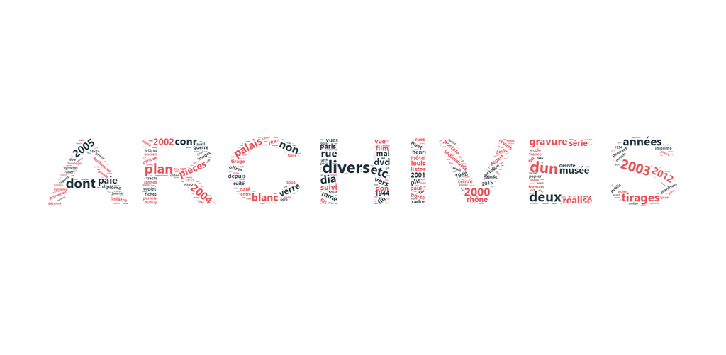

# Les données

|  | ID | nomArch | coteArch | dateEntree | statutJur | modeEntree | servProd | typeProd | activiteProd | descContenu | natureSupport | mlEntree | nbreArt | nature | dateYear |
| --- | --- | --- | --- | --- | --- | --- | --- | --- | --- | --- | --- | --- | --- | --- | --- |
| 1 | 1 | Archives municipales d'Avignon | 722W | 21/01/2003 | Archives publiques | Versement |  |  | Patrimoine historique | Dossiers expositions, journées du Patrimoine, dossiers divers, mémoires, correspondance, budgets, délibérations, chrono courrier départ et arrivée. Photos : 19 pochettes+ fiches bristol, 1 pochette (1… | Support papier | 7,5 | 57 | Archives publiques | 2003 |
| 2 | 2 | Archives municipales d'Avignon | 1E | 22/01/2003 | Archives publiques | Versement |  |  | Etat-civil | Registres et tables décennales naissances, mariages, décès année 1902. | Support mixte | 0,5 | 6 | Archives publiques | 2003 |
| 3 | 3 | Archives municipales d'Avignon | HSM | 22/01/2003 | Archives publiques | Versement |  |  | Centre hospitalier Henri Duffaut | Correspondance à intégrer dans le dossier de Madame ROGALSKI Véronique épouse RUYSSEN (K342) | Support papier | 0,01 | 1 | Archives publiques | 2003 |
| 4 | 4 | Archives municipales d'Avignon | W | 23/01/2003 | Archives publiques | Versement |  |  | Aménagement urbain | Copie de l'étude historique, de l'étude de réhabilitation et du schéma directeur d'aménagement, dossier bureau. | Support papier | 0,1 | 1 | Archives publiques | 2003 |
| 5 | 5 | Archives municipales d'Avignon | 724W | 07/02/2003 | Archives publiques | Versement |  |  | Action économique | Archives du service supprimé | Support papier | 20 | 40 | Archives publiques | 2003 |
| 6 | 6 | Archives municipales d'Avignon | 725W | 07/02/2003 | Archives publiques | Versement |  |  | Tourisme | Archives du service supprimé | Support papier | 17,2 | 22 | Archives publiques | 2003 |
| 7 | 7 | Archives municipales d'Avignon | 69Z | 07/02/2003 | Archives privées | Dépôt |  |  | SYCOVIA | Archives du syndicat avant dissolution | Support papier | 2,4 | 4 | Archives privées | 2003 |
| 8 | 8 | Archives municipales d'Avignon | 726W | 13/02/2003 | Archives publiques | Versement |  |  | Aménagement urbain | Dossiers M. DUBUY (16) ; Cartons M. MIRA (4) ; Dossiers Rocade DDE (10) ; Dossiers enquête TGV ; Panneaux et maquettes M. ALLARD, dossiers varia M. MALACHANE ; Photos expositions SAU. | Support papier | 18 | 70 | Archives publiques | 2003 |
| 9 | 9 | Archives municipales d'Avignon | 727W | 13/02/2003 | Archives publiques | Versement |  |  | Voirie circulation | 18 articles versés par le bureau de la règlementation : arrêtés de travaux, de manifestation, d'autorisation. | Support papier | 1,8 | 18 | Archives publiques | 2003 |
| 10 | 10 | Archives municipales d'Avignon | 728W | 13/02/2003 | Archives publiques | Versement |  |  | Voirie circulation | 19 articles d'arrêtés de stationnement et de circulation ; 4 articles d'autorisations d'occupation du domaine public. | Support papier | 2,3 | 23 | Archives publiques | 2003 |

[output cut: 1259 more lines]

# À propos du standard

En 2018, 86 kilomètres de documents et plus de 16000Go de données sont venus enrichir les collections des **services publics d’archives français** (données du *service interministériel des archives de France*).

Dans une optique de gestion et de suivi de leurs fonds, les services d’archives consignent chaque entrée d’archives à partir de renseignements sommaires permettant d’identifier et de retracer toutes les arrivées de nouveaux documents (provenance, date d’arrivée dans le service, volume…) : c’est le **registre des entrées**.

Il est généralement directement tenu au sein d’un système d’information dédié aux archives (le *SIA*), mais il peut également être réalisé avec un tableur voire sur un cahier.

Dans son **cadre stratégique commun de modernisation des archives**, la *délégation interministérielle aux archives de France* mentionne dans les objectifs 2020-2024 :

[output not shown]

Ainsi, en quelques mois, une équipe composée de représentants du SIAF, de l’AAF et de Datactivist a travaillé pour mettre au point un standard pour les données des **registres d’entrées**. Ce dernier n’a pas de caractère réglementaire mais son utilisation est recommandée dès lors qu’une réutilisation ou une comparaison des données est envisagée.

> Les colonnes à caractère **obligatoire** qui composent le standard :

`ID`

- **titre** : Identifiant unique de chaque entrée
- **description** : Identifiant unique de chaque entrée sous la forme : l’identifiant du service archives, année d’entrée et un identifiant unique (numéro incrémental, identifiant technique…).

`nomArch`

- **titre** : Nom du service archives
- **description** : Nom sous forme textuelle du service d’archives dans lequel sont entrées les archives

`dateEntree`

- **titre** : Date d’entrée
- **description** : Date à laquelle les documents sont entrés dans le service d’archives au format ISO8601

`statutJur`

- **titre** : Statut juridique des documents entrés
- **description** : Permet d’identifier la nature juridique des archives

`modeEntree`

- **titre** : Modalité d’entrée
- **description** : Permet d’identifier le mode d’entrée des archives

`servProd`

- **titre** : Service producteur
- **description** : Permet d’identifier la personne physique ou morale qui a produit les documents

`typeProd`

- **titre** : Fonction du producteur
- **description** : permet d’identifier la fonction du producteur, liste établie à partir des éléments du SIAF

`activiteProd`

- **titre** : Domaine ou thématique d’action du producteur
- **description** : Permet d’identifier le domaine d’activité du producteur, liste établie à partir des éléments du SIAF

`descContenu`

- **titre** : Description du contenu
- **description** : Permet de décrire le contenu des archives de l’entrée

`natureSupport`

- **titre** : Nature du support matériel des documents
- **description** : Permet d’indiquer de façon macro la typologie de support des documents

> Les colonnes à caractère **non obligatoire** qui composent le standard :

`coteArch`

- **titre** : Cotation
- **description** : Identifiant de l’entrée d’archives et correspondant à sa place dans le cadre de classement (série et sous-série)

`orgaVers`

- **titre** : Organisation qui verse l’entrée
- **description** : Nom de l’organisation qui a versé l’entrée, distincte du service qui a produit les entrées dans l’organisation.

`servVers`

- **titre** : Service qui verse l’entrée
- **description** : permet d’identifier la personne physique ou morale qui a transféré les documents

`orgaProd`

- **titre** : Organisation productrice de l’entrée
- **description** : nom de l’organisation qui a produit l’entrée, distincte du service qui a produit les entrées dans l’organisation.

`dateExD`

- **titre** : Date extrème de début
- **description** : Date du plus vieux document d’archives format AAAA

`dateExF`

- **titre** : Date extrème de fin
- **description** : Date du plus récent document d’archives format AAAA

`mlEntree`

- **titre** : Métrage linéaire de l’entrée
- **description** : Volume en mètre linéaire de l’entrée

`nbreArt`

- **titre** : Nombre d’articles
- **description** : Permet d’indiquer le nombre d’articles d’une entrée

`volElec`

- **titre** : Volume d’archives électroniques de l’entrée
- **description** : Correspond à la volumétrie de fichiers électroniques présents dans l’entrée en Go

`objElec`

- **titre** : Nombre d’objets électroniques
- **description** : Permet d’indiquer le nombre d’objets électroniques d’une entrée

> En résumé ce sont **20 variables** dont :
- 4 quantitatives
- 3 dates
- 13 qualitatives